# Risk Factor Analysis

## Outcome Variable

**Outcome Variable:** stunted

## Predictor Variables

**Intervention Variable:** month

**Adjustment Set:**

unadjusted

## Stratifying Variables

The analysis was stratified on these variable(s):

- agecat
- studyid
- country

## Data Summary

| agecat | studyid | country | month | stunted | n_cell | n | outcome_variable |
| --- | --- | --- | --- | --- | --- | --- | --- |
| Birth | ki0047075b-MAL-ED | BANGLADESH | 1 | 0 | 17 | 231 | stunted |
| Birth | ki0047075b-MAL-ED | BANGLADESH | 1 | 1 | 4 | 231 | stunted |
| Birth | ki0047075b-MAL-ED | BANGLADESH | 2 | 0 | 16 | 231 | stunted |
| Birth | ki0047075b-MAL-ED | BANGLADESH | 2 | 1 | 5 | 231 | stunted |
| Birth | ki0047075b-MAL-ED | BANGLADESH | 3 | 0 | 20 | 231 | stunted |
| Birth | ki0047075b-MAL-ED | BANGLADESH | 3 | 1 | 6 | 231 | stunted |
| Birth | ki0047075b-MAL-ED | BANGLADESH | 4 | 0 | 19 | 231 | stunted |
| Birth | ki0047075b-MAL-ED | BANGLADESH | 4 | 1 | 2 | 231 | stunted |
| Birth | ki0047075b-MAL-ED | BANGLADESH | 5 | 0 | 13 | 231 | stunted |
| Birth | ki0047075b-MAL-ED | BANGLADESH | 5 | 1 | 4 | 231 | stunted |
| Birth | ki0047075b-MAL-ED | BANGLADESH | 6 | 0 | 5 | 231 | stunted |
| Birth | ki0047075b-MAL-ED | BANGLADESH | 6 | 1 | 3 | 231 | stunted |
| Birth | ki0047075b-MAL-ED | BANGLADESH | 7 | 0 | 10 | 231 | stunted |
| Birth | ki0047075b-MAL-ED | BANGLADESH | 7 | 1 | 3 | 231 | stunted |
| Birth | ki0047075b-MAL-ED | BANGLADESH | 8 | 0 | 21 | 231 | stunted |
| Birth | ki0047075b-MAL-ED | BANGLADESH | 8 | 1 | 6 | 231 | stunted |
| Birth | ki0047075b-MAL-ED | BANGLADESH | 9 | 0 | 15 | 231 | stunted |
| Birth | ki0047075b-MAL-ED | BANGLADESH | 9 | 1 | 3 | 231 | stunted |
| Birth | ki0047075b-MAL-ED | BANGLADESH | 10 | 0 | 15 | 231 | stunted |
| Birth | ki0047075b-MAL-ED | BANGLADESH | 10 | 1 | 5 | 231 | stunted |
| Birth | ki0047075b-MAL-ED | BANGLADESH | 11 | 0 | 13 | 231 | stunted |
| Birth | ki0047075b-MAL-ED | BANGLADESH | 11 | 1 | 0 | 231 | stunted |
| Birth | ki0047075b-MAL-ED | BANGLADESH | 12 | 0 | 23 | 231 | stunted |
| Birth | ki0047075b-MAL-ED | BANGLADESH | 12 | 1 | 3 | 231 | stunted |
| Birth | ki0047075b-MAL-ED | BRAZIL | 1 | 0 | 4 | 65 | stunted |
| Birth | ki0047075b-MAL-ED | BRAZIL | 1 | 1 | 1 | 65 | stunted |
| Birth | ki0047075b-MAL-ED | BRAZIL | 2 | 0 | 8 | 65 | stunted |
| Birth | ki0047075b-MAL-ED | BRAZIL | 2 | 1 | 0 | 65 | stunted |
| Birth | ki0047075b-MAL-ED | BRAZIL | 3 | 0 | 9 | 65 | stunted |
| Birth | ki0047075b-MAL-ED | BRAZIL | 3 | 1 | 0 | 65 | stunted |

[output cut: 1578 more lines]

The following strata were considered:

- agecat: 24 months, studyid: ki0047075b-MAL-ED, country: BANGLADESH
- agecat: 24 months, studyid: ki0047075b-MAL-ED, country: BRAZIL
- agecat: 24 months, studyid: ki0047075b-MAL-ED, country: INDIA
- agecat: 24 months, studyid: ki0047075b-MAL-ED, country: NEPAL
- agecat: 24 months, studyid: ki0047075b-MAL-ED, country: PERU
- agecat: 24 months, studyid: ki0047075b-MAL-ED, country: SOUTH AFRICA
- agecat: 24 months, studyid: ki0047075b-MAL-ED, country: TANZANIA, UNITED REPUBLIC OF
- agecat: 24 months, studyid: ki1000108-CMC-V-BCS-2002, country: INDIA
- agecat: 24 months, studyid: ki1000108-IRC, country: INDIA
- agecat: 24 months, studyid: ki1000109-EE, country: PAKISTAN
- agecat: 24 months, studyid: ki1017093-NIH-Birth, country: BANGLADESH
- agecat: 24 months, studyid: ki1066203-TanzaniaChild2, country: TANZANIA, UNITED REPUBLIC OF
- agecat: 24 months, studyid: ki1101329-Keneba, country: GAMBIA
- agecat: 24 months, studyid: ki1113344-GMS-Nepal, country: NEPAL
- agecat: 24 months, studyid: ki1114097-CMIN, country: BANGLADESH
- agecat: 24 months, studyid: ki1114097-CONTENT, country: PERU
- agecat: 24 months, studyid: ki1119695-PROBIT, country: BELARUS
- agecat: 24 months, studyid: ki1126311-ZVITAMBO, country: ZIMBABWE
- agecat: 24 months, studyid: ki1148112-LCNI-5, country: MALAWI
- agecat: 24 months, studyid: kiGH5241-JiVitA-3, country: BANGLADESH
- agecat: 24 months, studyid: kiGH5241-JiVitA-4, country: BANGLADESH
- agecat: 6 months, studyid: ki0047075b-MAL-ED, country: BANGLADESH
- agecat: 6 months, studyid: ki0047075b-MAL-ED, country: BRAZIL
- agecat: 6 months, studyid: ki0047075b-MAL-ED, country: INDIA
- agecat: 6 months, studyid: ki0047075b-MAL-ED, country: NEPAL
- agecat: 6 months, studyid: ki0047075b-MAL-ED, country: PERU
- agecat: 6 months, studyid: ki0047075b-MAL-ED, country: SOUTH AFRICA
- agecat: 6 months, studyid: ki0047075b-MAL-ED, country: TANZANIA, UNITED REPUBLIC OF
- agecat: 6 months, studyid: ki1000108-CMC-V-BCS-2002, country: INDIA
- agecat: 6 months, studyid: ki1000108-IRC, country: INDIA
- agecat: 6 months, studyid: ki1000109-EE, country: PAKISTAN
- agecat: 6 months, studyid: ki1000109-ResPak, country: PAKISTAN
- agecat: 6 months, studyid: ki1000304b-SAS-CompFeed, country: INDIA
- agecat: 6 months, studyid: ki1000304b-SAS-FoodSuppl, country: INDIA
- agecat: 6 months, studyid: ki1017093-NIH-Birth, country: BANGLADESH
- agecat: 6 months, studyid: ki1066203-TanzaniaChild2, country: TANZANIA, UNITED REPUBLIC OF
- agecat: 6 months, studyid: ki1101329-Keneba, country: GAMBIA
- agecat: 6 months, studyid: ki1112895-Guatemala BSC, country: GUATEMALA
- agecat: 6 months, studyid: ki1113344-GMS-Nepal, country: NEPAL
- agecat: 6 months, studyid: ki1114097-CMIN, country: BANGLADESH
- agecat: 6 months, studyid: ki1114097-CONTENT, country: PERU
- agecat: 6 months, studyid: ki1119695-PROBIT, country: BELARUS
- agecat: 6 months, studyid: ki1126311-ZVITAMBO, country: ZIMBABWE
- agecat: 6 months, studyid: ki1148112-LCNI-5, country: MALAWI
- agecat: 6 months, studyid: kiGH5241-JiVitA-3, country: BANGLADESH
- agecat: 6 months, studyid: kiGH5241-JiVitA-4, country: BANGLADESH
- agecat: Birth, studyid: ki0047075b-MAL-ED, country: BANGLADESH
- agecat: Birth, studyid: ki0047075b-MAL-ED, country: BRAZIL
- agecat: Birth, studyid: ki0047075b-MAL-ED, country: INDIA
- agecat: Birth, studyid: ki0047075b-MAL-ED, country: NEPAL
- agecat: Birth, studyid: ki0047075b-MAL-ED, country: PERU
- agecat: Birth, studyid: ki0047075b-MAL-ED, country: SOUTH AFRICA
- agecat: Birth, studyid: ki0047075b-MAL-ED, country: TANZANIA, UNITED REPUBLIC OF
- agecat: Birth, studyid: ki1000108-CMC-V-BCS-2002, country: INDIA
- agecat: Birth, studyid: ki1000108-IRC, country: INDIA
- agecat: Birth, studyid: ki1000109-EE, country: PAKISTAN
- agecat: Birth, studyid: ki1000109-ResPak, country: PAKISTAN
- agecat: Birth, studyid: ki1000304b-SAS-CompFeed, country: INDIA
- agecat: Birth, studyid: ki1017093-NIH-Birth, country: BANGLADESH
- agecat: Birth, studyid: ki1101329-Keneba, country: GAMBIA
- agecat: Birth, studyid: ki1113344-GMS-Nepal, country: NEPAL
- agecat: Birth, studyid: ki1114097-CMIN, country: BANGLADESH
- agecat: Birth, studyid: ki1114097-CONTENT, country: PERU
- agecat: Birth, studyid: ki1119695-PROBIT, country: BELARUS
- agecat: Birth, studyid: ki1126311-ZVITAMBO, country: ZIMBABWE
- agecat: Birth, studyid: kiGH5241-JiVitA-3, country: BANGLADESH
- agecat: Birth, studyid: kiGH5241-JiVitA-4, country: BANGLADESH

### Dropped Strata

Some strata were dropped due to rare outcomes:

- agecat: Birth, studyid: ki0047075b-MAL-ED, country: BANGLADESH
- agecat: Birth, studyid: ki0047075b-MAL-ED, country: BRAZIL
- agecat: Birth, studyid: ki0047075b-MAL-ED, country: INDIA
- agecat: Birth, studyid: ki0047075b-MAL-ED, country: NEPAL
- agecat: Birth, studyid: ki0047075b-MAL-ED, country: PERU
- agecat: Birth, studyid: ki0047075b-MAL-ED, country: SOUTH AFRICA
- agecat: Birth, studyid: ki0047075b-MAL-ED, country: TANZANIA, UNITED REPUBLIC OF
- agecat: Birth, studyid: ki1000108-CMC-V-BCS-2002, country: INDIA
- agecat: Birth, studyid: ki1000108-IRC, country: INDIA
- agecat: Birth, studyid: ki1000109-EE, country: PAKISTAN
- agecat: Birth, studyid: ki1000109-ResPak, country: PAKISTAN
- agecat: Birth, studyid: ki1101329-Keneba, country: GAMBIA
- agecat: Birth, studyid: ki1113344-GMS-Nepal, country: NEPAL
- agecat: Birth, studyid: ki1114097-CMIN, country: BANGLADESH
- agecat: Birth, studyid: ki1114097-CONTENT, country: PERU
- agecat: Birth, studyid: ki1119695-PROBIT, country: BELARUS
- agecat: Birth, studyid: kiGH5241-JiVitA-4, country: BANGLADESH
- agecat: 6 months, studyid: ki0047075b-MAL-ED, country: BANGLADESH
- agecat: 6 months, studyid: ki0047075b-MAL-ED, country: BRAZIL
- agecat: 6 months, studyid: ki0047075b-MAL-ED, country: INDIA
- agecat: 6 months, studyid: ki0047075b-MAL-ED, country: NEPAL
- agecat: 6 months, studyid: ki0047075b-MAL-ED, country: PERU
- agecat: 6 months, studyid: ki0047075b-MAL-ED, country: SOUTH AFRICA
- agecat: 6 months, studyid: ki0047075b-MAL-ED, country: TANZANIA, UNITED REPUBLIC OF
- agecat: 6 months, studyid: ki1000108-CMC-V-BCS-2002, country: INDIA
- agecat: 6 months, studyid: ki1000109-EE, country: PAKISTAN
- agecat: 6 months, studyid: ki1000109-ResPak, country: PAKISTAN
- agecat: 6 months, studyid: ki1000304b-SAS-FoodSuppl, country: INDIA
- agecat: 6 months, studyid: ki1112895-Guatemala BSC, country: GUATEMALA
- agecat: 6 months, studyid: ki1113344-GMS-Nepal, country: NEPAL
- agecat: 6 months, studyid: ki1114097-CMIN, country: BANGLADESH
- agecat: 6 months, studyid: ki1114097-CONTENT, country: PERU
- agecat: 24 months, studyid: ki0047075b-MAL-ED, country: BANGLADESH
- agecat: 24 months, studyid: ki0047075b-MAL-ED, country: BRAZIL
- agecat: 24 months, studyid: ki0047075b-MAL-ED, country: INDIA
- agecat: 24 months, studyid: ki0047075b-MAL-ED, country: NEPAL
- agecat: 24 months, studyid: ki0047075b-MAL-ED, country: PERU
- agecat: 24 months, studyid: ki0047075b-MAL-ED, country: SOUTH AFRICA
- agecat: 24 months, studyid: ki0047075b-MAL-ED, country: TANZANIA, UNITED REPUBLIC OF
- agecat: 24 months, studyid: ki1000108-CMC-V-BCS-2002, country: INDIA
- agecat: 24 months, studyid: ki1000108-IRC, country: INDIA
- agecat: 24 months, studyid: ki1000109-EE, country: PAKISTAN
- agecat: 24 months, studyid: ki1066203-TanzaniaChild2, country: TANZANIA, UNITED REPUBLIC OF
- agecat: 24 months, studyid: ki1113344-GMS-Nepal, country: NEPAL
- agecat: 24 months, studyid: ki1114097-CMIN, country: BANGLADESH
- agecat: 24 months, studyid: ki1114097-CONTENT, country: PERU

## Methods Detail

We’re interested in the causal parameters $E[Y_a]$ for all values of $a \in \mathcal{A}$. These parameters represent the mean outcome if, possibly contrary to fact, we intervened to set all units to have $A=a$. Under the randomization and positivity assumptions, these are identified by the statistical parameters $\psi_a=E_W[E_{Y|A,W}(Y|A=a,W)]$. In addition, we’re interested in the mean of $Y$, $E[Y]$ under no intervention (the observed mean). We will estimate these parameters by using SuperLearner to fit the relevant likelihood factors – $E_{Y|A,W}(Y|A=a,W)$ and $p(A=a|W)$, and then updating our likelihood fit using a joint TMLE.

For unadjusted analyses ($W=\{\}$), initial likelihoods were estimated using Lrnr_glm to estimate the simple $E(Y|A)$ and Lrnr_mean to estimate $p(A)$. For adjusted analyses, a small library containing Lrnr_glmnet, Lrnr_xgboost, and Lrnr_mean was used.

Having estimated these parameters, we will then use the delta method to estimate relative risks and attributable risks relative to a prespecified baseline level of $A$.

# Results Detail

## Results Plots

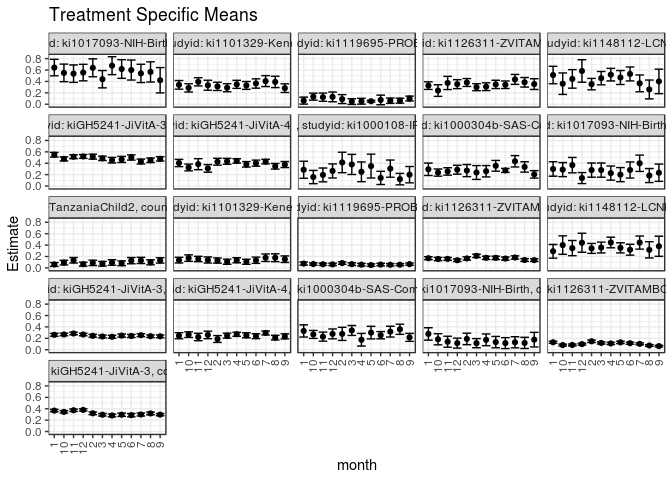

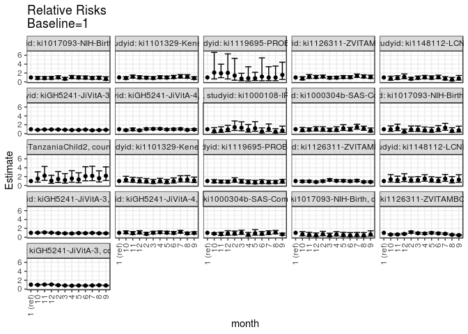

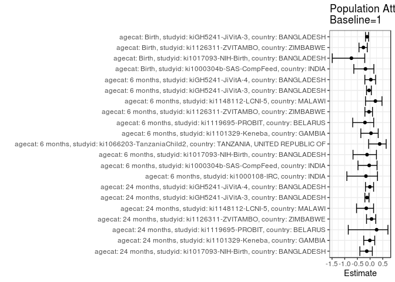

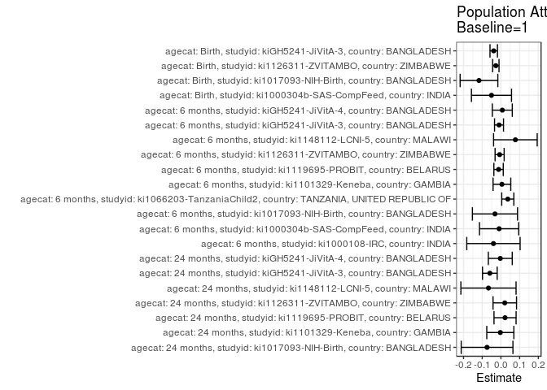

## Results Table

### Parameter: TSM

| agecat | studyid | country | intervention_level | baseline_level | estimate | ci_lower | ci_upper |
| --- | --- | --- | --- | --- | --- | --- | --- |
| Birth | ki1000304b-SAS-CompFeed | INDIA | 1 | NA | 0.3292683 | 0.2225822 | 0.4359544 |
| Birth | ki1000304b-SAS-CompFeed | INDIA | 2 | NA | 0.2777778 | 0.1625089 | 0.3930467 |
| Birth | ki1000304b-SAS-CompFeed | INDIA | 3 | NA | 0.3375000 | 0.2508382 | 0.4241618 |
| Birth | ki1000304b-SAS-CompFeed | INDIA | 4 | NA | 0.1746032 | 0.0638137 | 0.2853927 |
| Birth | ki1000304b-SAS-CompFeed | INDIA | 5 | NA | 0.3000000 | 0.1897606 | 0.4102394 |
| Birth | ki1000304b-SAS-CompFeed | INDIA | 6 | NA | 0.2549020 | 0.1913523 | 0.3184517 |
| Birth | ki1000304b-SAS-CompFeed | INDIA | 7 | NA | 0.3168317 | 0.2222655 | 0.4113979 |
| Birth | ki1000304b-SAS-CompFeed | INDIA | 8 | NA | 0.3586207 | 0.2690571 | 0.4481842 |
| Birth | ki1000304b-SAS-CompFeed | INDIA | 9 | NA | 0.2162162 | 0.1462510 | 0.2861815 |
| Birth | ki1000304b-SAS-CompFeed | INDIA | 10 | NA | 0.2681159 | 0.1975360 | 0.3386959 |
| Birth | ki1000304b-SAS-CompFeed | INDIA | 11 | NA | 0.2295082 | 0.1503240 | 0.3086924 |
| Birth | ki1000304b-SAS-CompFeed | INDIA | 12 | NA | 0.2773109 | 0.1908828 | 0.3637391 |
| Birth | ki1017093-NIH-Birth | BANGLADESH | 1 | NA | 0.2769231 | 0.1680500 | 0.3857962 |
| Birth | ki1017093-NIH-Birth | BANGLADESH | 2 | NA | 0.1896552 | 0.0886813 | 0.2906290 |
| Birth | ki1017093-NIH-Birth | BANGLADESH | 3 | NA | 0.1147541 | 0.0347050 | 0.1948032 |
| Birth | ki1017093-NIH-Birth | BANGLADESH | 4 | NA | 0.1730769 | 0.0701673 | 0.2759865 |
| Birth | ki1017093-NIH-Birth | BANGLADESH | 5 | NA | 0.1333333 | 0.0339314 | 0.2327352 |
| Birth | ki1017093-NIH-Birth | BANGLADESH | 6 | NA | 0.1162791 | 0.0203877 | 0.2121705 |
| Birth | ki1017093-NIH-Birth | BANGLADESH | 7 | NA | 0.1304348 | 0.0330313 | 0.2278382 |
| Birth | ki1017093-NIH-Birth | BANGLADESH | 8 | NA | 0.1190476 | 0.0210270 | 0.2170682 |
| Birth | ki1017093-NIH-Birth | BANGLADESH | 9 | NA | 0.1764706 | 0.0482252 | 0.3047160 |
| Birth | ki1017093-NIH-Birth | BANGLADESH | 10 | NA | 0.1833333 | 0.0853453 | 0.2813214 |
| Birth | ki1017093-NIH-Birth | BANGLADESH | 11 | NA | 0.1400000 | 0.0437427 | 0.2362573 |
| Birth | ki1017093-NIH-Birth | BANGLADESH | 12 | NA | 0.1153846 | 0.0284776 | 0.2022917 |
| Birth | ki1126311-ZVITAMBO | ZIMBABWE | 1 | NA | 0.1304670 | 0.1124927 | 0.1484413 |
| Birth | ki1126311-ZVITAMBO | ZIMBABWE | 2 | NA | 0.1479347 | 0.1263667 | 0.1695027 |
| Birth | ki1126311-ZVITAMBO | ZIMBABWE | 3 | NA | 0.1188811 | 0.1001258 | 0.1376364 |
| Birth | ki1126311-ZVITAMBO | ZIMBABWE | 4 | NA | 0.1094675 | 0.0902493 | 0.1286856 |
| Birth | ki1126311-ZVITAMBO | ZIMBABWE | 5 | NA | 0.1284861 | 0.1077865 | 0.1491857 |
| Birth | ki1126311-ZVITAMBO | ZIMBABWE | 6 | NA | 0.1136564 | 0.0951908 | 0.1321220 |

[output cut: 222 more lines]

### Parameter: E(Y)

| agecat | studyid | country | intervention_level | baseline_level | estimate | ci_lower | ci_upper |
| --- | --- | --- | --- | --- | --- | --- | --- |
| Birth | ki1000304b-SAS-CompFeed | INDIA | NA | NA | 0.2787540 | 0.2475949 | 0.3099131 |
| Birth | ki1017093-NIH-Birth | BANGLADESH | NA | NA | 0.1595395 | 0.1304091 | 0.1886699 |
| Birth | ki1126311-ZVITAMBO | ZIMBABWE | NA | NA | 0.1033514 | 0.0982859 | 0.1084168 |
| Birth | kiGH5241-JiVitA-3 | BANGLADESH | NA | NA | 0.3289690 | 0.3216017 | 0.3363364 |
| 6 months | ki1000108-IRC | INDIA | NA | NA | 0.2457002 | 0.2038248 | 0.2875757 |
| 6 months | ki1000304b-SAS-CompFeed | INDIA | NA | NA | 0.2844311 | 0.2666491 | 0.3022132 |
| 6 months | ki1017093-NIH-Birth | BANGLADESH | NA | NA | 0.2681564 | 0.2306532 | 0.3056597 |
| 6 months | ki1066203-TanzaniaChild2 | TANZANIA, UNITED REPUBLIC OF | NA | NA | 0.0970922 | 0.0842059 | 0.1099785 |
| 6 months | ki1101329-Keneba | GAMBIA | NA | NA | 0.1412159 | 0.1262788 | 0.1561530 |
| 6 months | ki1119695-PROBIT | BELARUS | NA | NA | 0.0626864 | 0.0488489 | 0.0765239 |
| 6 months | ki1126311-ZVITAMBO | ZIMBABWE | NA | NA | 0.1628792 | 0.1551057 | 0.1706527 |
| 6 months | ki1148112-LCNI-5 | MALAWI | NA | NA | 0.3682956 | 0.3356382 | 0.4009530 |
| 6 months | kiGH5241-JiVitA-3 | BANGLADESH | NA | NA | 0.2513830 | 0.2432594 | 0.2595066 |
| 6 months | kiGH5241-JiVitA-4 | BANGLADESH | NA | NA | 0.2527427 | 0.2386864 | 0.2667990 |
| 24 months | ki1017093-NIH-Birth | BANGLADESH | NA | NA | 0.5687646 | 0.5218455 | 0.6156837 |
| 24 months | ki1101329-Keneba | GAMBIA | NA | NA | 0.3368116 | 0.3145020 | 0.3591212 |
| 24 months | ki1119695-PROBIT | BELARUS | NA | NA | 0.0852540 | 0.0554439 | 0.1150642 |
| 24 months | ki1126311-ZVITAMBO | ZIMBABWE | NA | NA | 0.3469512 | 0.3239068 | 0.3699956 |
| 24 months | ki1148112-LCNI-5 | MALAWI | NA | NA | 0.4455959 | 0.4050760 | 0.4861157 |
| 24 months | kiGH5241-JiVitA-3 | BANGLADESH | NA | NA | 0.4910797 | 0.4779658 | 0.5041936 |
| 24 months | kiGH5241-JiVitA-4 | BANGLADESH | NA | NA | 0.4008838 | 0.3839145 | 0.4178532 |

### Parameter: RR

| agecat | studyid | country | intervention_level | baseline_level | estimate | ci_lower | ci_upper |
| --- | --- | --- | --- | --- | --- | --- | --- |
| Birth | ki1000304b-SAS-CompFeed | INDIA | 1 | 1 | 1.0000000 | 1.0000000 | 1.0000000 |
| Birth | ki1000304b-SAS-CompFeed | INDIA | 2 | 1 | 0.8436214 | 0.5081881 | 1.4004599 |
| Birth | ki1000304b-SAS-CompFeed | INDIA | 3 | 1 | 1.0250000 | 0.6602771 | 1.5911880 |
| Birth | ki1000304b-SAS-CompFeed | INDIA | 4 | 1 | 0.5302763 | 0.2554464 | 1.1007906 |
| Birth | ki1000304b-SAS-CompFeed | INDIA | 5 | 1 | 0.9111111 | 0.4823734 | 1.7209146 |
| Birth | ki1000304b-SAS-CompFeed | INDIA | 6 | 1 | 0.7741467 | 0.4609291 | 1.3002066 |
| Birth | ki1000304b-SAS-CompFeed | INDIA | 7 | 1 | 0.9622296 | 0.6340766 | 1.4602111 |
| Birth | ki1000304b-SAS-CompFeed | INDIA | 8 | 1 | 1.0891443 | 0.7717946 | 1.5369832 |
| Birth | ki1000304b-SAS-CompFeed | INDIA | 9 | 1 | 0.6566567 | 0.4641897 | 0.9289262 |
| Birth | ki1000304b-SAS-CompFeed | INDIA | 10 | 1 | 0.8142780 | 0.6535612 | 1.0145168 |
| Birth | ki1000304b-SAS-CompFeed | INDIA | 11 | 1 | 0.6970249 | 0.4233748 | 1.1475500 |
| Birth | ki1000304b-SAS-CompFeed | INDIA | 12 | 1 | 0.8422035 | 0.4814265 | 1.4733440 |
| Birth | ki1017093-NIH-Birth | BANGLADESH | 1 | 1 | 1.0000000 | 1.0000000 | 1.0000000 |
| Birth | ki1017093-NIH-Birth | BANGLADESH | 2 | 1 | 0.6848659 | 0.3533245 | 1.3275084 |
| Birth | ki1017093-NIH-Birth | BANGLADESH | 3 | 1 | 0.4143898 | 0.1860608 | 0.9229185 |
| Birth | ki1017093-NIH-Birth | BANGLADESH | 4 | 1 | 0.6250000 | 0.3064138 | 1.2748282 |
| Birth | ki1017093-NIH-Birth | BANGLADESH | 5 | 1 | 0.4814815 | 0.2072734 | 1.1184474 |
| Birth | ki1017093-NIH-Birth | BANGLADESH | 6 | 1 | 0.4198966 | 0.1684132 | 1.0469084 |
| Birth | ki1017093-NIH-Birth | BANGLADESH | 7 | 1 | 0.4710145 | 0.2025441 | 1.0953398 |
| Birth | ki1017093-NIH-Birth | BANGLADESH | 8 | 1 | 0.4298942 | 0.1726243 | 1.0705849 |
| Birth | ki1017093-NIH-Birth | BANGLADESH | 9 | 1 | 0.6372549 | 0.2789172 | 1.4559654 |
| Birth | ki1017093-NIH-Birth | BANGLADESH | 10 | 1 | 0.6620370 | 0.3409777 | 1.2854011 |
| Birth | ki1017093-NIH-Birth | BANGLADESH | 11 | 1 | 0.5055556 | 0.2289805 | 1.1161930 |
| Birth | ki1017093-NIH-Birth | BANGLADESH | 12 | 1 | 0.4166667 | 0.1781555 | 0.9744923 |
| Birth | ki1126311-ZVITAMBO | ZIMBABWE | 1 | 1 | 1.0000000 | 1.0000000 | 1.0000000 |
| Birth | ki1126311-ZVITAMBO | ZIMBABWE | 2 | 1 | 1.1338857 | 0.9278001 | 1.3857476 |
| Birth | ki1126311-ZVITAMBO | ZIMBABWE | 3 | 1 | 0.9111968 | 0.7390067 | 1.1235075 |
| Birth | ki1126311-ZVITAMBO | ZIMBABWE | 4 | 1 | 0.8390432 | 0.6712215 | 1.0488244 |
| Birth | ki1126311-ZVITAMBO | ZIMBABWE | 5 | 1 | 0.9848164 | 0.7966992 | 1.2173519 |
| Birth | ki1126311-ZVITAMBO | ZIMBABWE | 6 | 1 | 0.8711504 | 0.7040134 | 1.0779666 |

[output cut: 222 more lines]

### Parameter: PAR

| agecat | studyid | country | intervention_level | baseline_level | estimate | ci_lower | ci_upper |
| --- | --- | --- | --- | --- | --- | --- | --- |
| Birth | ki1000304b-SAS-CompFeed | INDIA | 1 | NA | -0.0505143 | -0.1576857 | 0.0566571 |
| Birth | ki1017093-NIH-Birth | BANGLADESH | 1 | NA | -0.1173836 | -0.2182176 | -0.0165496 |
| Birth | ki1126311-ZVITAMBO | ZIMBABWE | 1 | NA | -0.0271157 | -0.0440246 | -0.0102068 |
| Birth | kiGH5241-JiVitA-3 | BANGLADESH | 1 | NA | -0.0384552 | -0.0584097 | -0.0185007 |
| 6 months | ki1000108-IRC | INDIA | 1 | NA | -0.0400140 | -0.1826534 | 0.1026253 |
| 6 months | ki1000304b-SAS-CompFeed | INDIA | 1 | NA | -0.0096865 | -0.1145821 | 0.0952091 |
| 6 months | ki1017093-NIH-Birth | BANGLADESH | 1 | NA | -0.0318436 | -0.1525110 | 0.0888238 |
| 6 months | ki1066203-TanzaniaChild2 | TANZANIA, UNITED REPUBLIC OF | 1 | NA | 0.0367907 | 0.0044521 | 0.0691292 |
| 6 months | ki1101329-Keneba | GAMBIA | 1 | NA | 0.0053463 | -0.0420191 | 0.0527118 |
| 6 months | ki1119695-PROBIT | BELARUS | 1 | NA | -0.0126312 | -0.0377001 | 0.0124377 |
| 6 months | ki1126311-ZVITAMBO | ZIMBABWE | 1 | NA | -0.0070003 | -0.0312529 | 0.0172523 |
| 6 months | ki1148112-LCNI-5 | MALAWI | 1 | NA | 0.0773865 | -0.0392330 | 0.1940060 |
| 6 months | kiGH5241-JiVitA-3 | BANGLADESH | 1 | NA | -0.0101554 | -0.0341467 | 0.0138358 |
| 6 months | kiGH5241-JiVitA-4 | BANGLADESH | 1 | NA | 0.0074597 | -0.0458324 | 0.0607517 |
| 24 months | ki1017093-NIH-Birth | BANGLADESH | 1 | NA | -0.0740926 | -0.2123979 | 0.0642127 |
| 24 months | ki1101329-Keneba | GAMBIA | 1 | NA | -0.0031884 | -0.0756304 | 0.0692536 |
| 24 months | ki1119695-PROBIT | BELARUS | 1 | NA | 0.0220570 | -0.0370199 | 0.0811339 |
| 24 months | ki1126311-ZVITAMBO | ZIMBABWE | 1 | NA | 0.0206354 | -0.0421970 | 0.0834679 |
| 24 months | ki1148112-LCNI-5 | MALAWI | 1 | NA | -0.0665993 | -0.2141488 | 0.0809503 |
| 24 months | kiGH5241-JiVitA-3 | BANGLADESH | 1 | NA | -0.0592749 | -0.0985603 | -0.0199895 |
| 24 months | kiGH5241-JiVitA-4 | BANGLADESH | 1 | NA | -0.0033715 | -0.0672904 | 0.0605474 |

### Parameter: PAF

| agecat | studyid | country | intervention_level | baseline_level | estimate | ci_lower | ci_upper |
| --- | --- | --- | --- | --- | --- | --- | --- |
| Birth | ki1000304b-SAS-CompFeed | INDIA | 1 | NA | -0.1812146 | -0.6408627 | 0.1496742 |
| Birth | ki1017093-NIH-Birth | BANGLADESH | 1 | NA | -0.7357653 | -1.4911769 | -0.2094208 |
| Birth | ki1126311-ZVITAMBO | ZIMBABWE | 1 | NA | -0.2623639 | -0.4366368 | -0.1092314 |
| Birth | kiGH5241-JiVitA-3 | BANGLADESH | 1 | NA | -0.1168961 | -0.1792777 | -0.0578143 |
| 6 months | ki1000108-IRC | INDIA | 1 | NA | -0.1628571 | -0.9155012 | 0.2940559 |
| 6 months | ki1000304b-SAS-CompFeed | INDIA | 1 | NA | -0.0340557 | -0.4766617 | 0.2758861 |
| 6 months | ki1017093-NIH-Birth | BANGLADESH | 1 | NA | -0.1187500 | -0.6726134 | 0.2517090 |
| 6 months | ki1066203-TanzaniaChild2 | TANZANIA, UNITED REPUBLIC OF | 1 | NA | 0.3789251 | -0.0561745 | 0.6347819 |
| 6 months | ki1101329-Keneba | GAMBIA | 1 | NA | 0.0378592 | -0.3634225 | 0.3210360 |
| 6 months | ki1119695-PROBIT | BELARUS | 1 | NA | -0.2014987 | -0.6850686 | 0.1432994 |
| 6 months | ki1126311-ZVITAMBO | ZIMBABWE | 1 | NA | -0.0429784 | -0.2030210 | 0.0957731 |
| 6 months | ki1148112-LCNI-5 | MALAWI | 1 | NA | 0.2101206 | -0.1793339 | 0.4709646 |
| 6 months | kiGH5241-JiVitA-3 | BANGLADESH | 1 | NA | -0.0403983 | -0.1403883 | 0.0508246 |
| 6 months | kiGH5241-JiVitA-4 | BANGLADESH | 1 | NA | 0.0295149 | -0.2057481 | 0.2188740 |
| 24 months | ki1017093-NIH-Birth | BANGLADESH | 1 | NA | -0.1302693 | -0.4021592 | 0.0888990 |
| 24 months | ki1101329-Keneba | GAMBIA | 1 | NA | -0.0094664 | -0.2491792 | 0.1842464 |
| 24 months | ki1119695-PROBIT | BELARUS | 1 | NA | 0.2587209 | -0.8596739 | 0.7045210 |
| 24 months | ki1126311-ZVITAMBO | ZIMBABWE | 1 | NA | 0.0594765 | -0.1402328 | 0.2242071 |
| 24 months | ki1148112-LCNI-5 | MALAWI | 1 | NA | -0.1494611 | -0.5335293 | 0.1384182 |
| 24 months | kiGH5241-JiVitA-3 | BANGLADESH | 1 | NA | -0.1207032 | -0.2037888 | -0.0433522 |
| 24 months | kiGH5241-JiVitA-4 | BANGLADESH | 1 | NA | -0.0084101 | -0.1812155 | 0.1391147 |